# Demonstration of single cell data processing on the pancreas data

Yongjin Park

2020-01-29 16:31:21

We assume the following executable files are properly installed:

- `mmutil_merge_col`
- `mmutil_filter_row`
- `mmutil_spectral_cluster_col`

## Preprocessing

Create a working directory:

```bash
[ -d example/pancreas_2018-08-13/ ] || mkdir -p example/pancreas_2018-08-13/
```

### Merge multiple data files

```bash
export BATCHES=$(ls -1 data/pancreas_2018-08-13/*.mtx.gz | xargs -I file basename file .mtx.gz)

if ! [ -f example/pancreas_2018-08-13/genes.tsv.gz ] ; then
    zcat data/pancreas_2018-08-13/*_genes.tsv.gz | \
    awk '{ genes[$2]=1 } END { for(g in genes) print g }' | \
    sort | \
    gzip > example/pancreas_2018-08-13/genes.tsv.gz
fi

for b in $BATCHES; do
    [ -f example/pancreas_2018-08-13/${b}_genes.tsv.gz ] || gzip -cd data/pancreas_2018-08-13/${b}_genes.tsv.gz | awk '{ print $2 }' | gzip > example/pancreas_2018-08-13/${b}_genes.tsv.gz

    [ -f example/pancreas_2018-08-13/${b}_barcodes.tsv.gz ] || gzip -cd data/pancreas_2018-08-13/${b}_barcodes.tsv.gz | awk -v batch=${b} -F'-' '{ print $1 FS batch }' | gzip > example/pancreas_2018-08-13/${b}_barcodes.tsv.gz
done

if ! [ -f example/pancreas_2018-08-13/merged.mtx.gz ]; then

    mmutil_merge_col \
        example/pancreas_2018-08-13/genes.tsv.gz 500 \
        example/pancreas_2018-08-13/merged \
        $(echo $BATCHES | sed 's/ /\n/g' | awk '{ print "data/pancreas_2018-08-13/" $1 ".mtx.gz" FS  "example/pancreas_2018-08-13/" $1 "_genes.tsv.gz" FS "example/pancreas_2018-08-13/" $1 "_barcodes.tsv.gz" }')

fi
```

[output not shown]

[output cut: 690 more lines]

[output not shown]

### Select top `10000` most variable features

```bash
if ! [ -f example/pancreas_2018-08-13/top.mtx.gz ]; then
    mmutil_filter_row 10000 \
    example/pancreas_2018-08-13/merged.mtx.gz \
    example/pancreas_2018-08-13/merged.rows.gz \
    example/pancreas_2018-08-13/top \
    2> /dev/null
fi

# just copy the barcode file to be consistent
if ! [ -f example/pancreas_2018-08-13/top.barcodes.tsv.gz ]; then
    zcat example/pancreas_2018-08-13/merged.columns.gz | \
    awk '{ print $1 }' | \
    gzip > example/pancreas_2018-08-13/top.barcodes.tsv.gz
fi
```

Show the full spectrum of the feature scores:

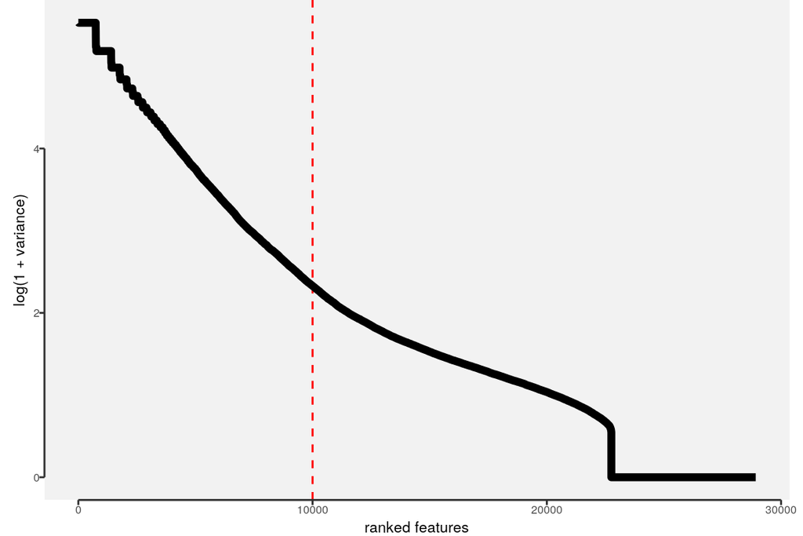

```r
out.dir = "example/pancreas_2018-08-13/"

var.scores = out.dir %&% "top.full_scores.gz" %>%
    read_tsv(col_names="var", col_types="d") %>%
    mutate(idx = 1:n())

.gg.plot(var.scores, aes(x=idx, y=log(1 + var))) +
    geom_vline(xintercept=10000, lty=2, col='red') +
    geom_line(size=2) +
    ylab("log(1 + variance)") +
    xlab("ranked features")
```

## Run clustering combining all together

Let’s visualize clustering results with the following function:

```r
.show.scatter = function(.argmax, .embed) {

    argmax.tab = fread(.argmax) %>%
        (function(x) { colnames(x) = c("TAG", "k"); x })

    embedded.tab = fread(.embed) %>%
        (function(x) { colnames(x) = c("e1", "e2"); x })

    ## Show 2D embedding of those clusters of cells

    .K = max(argmax.tab$k)
    .lab = c("cluster" %&% 1:.K, "unassigned")

    argmax.tab = argmax.tab[, k := factor(k, c(1:.K, -1), .lab)]

    .dt = cbind(argmax.tab, embedded.tab) %>%
        na.omit() %>%
        filter(k != "unassigned")

    p1 =
        .gg.plot(.dt, aes(x=e1, y=e2, color=as.factor(k))) +
        theme(legend.title=element_blank()) +
        theme(legend.position=c(1,1), legend.justification=c(1,1)) +
        geom_point(size=.5)

    print(p1)

    ## show some labels
    .df = as_tibble(.dt) %>%
        separate("TAG", c("barcode", "state"), sep="[-]") %>%
        filter(k != "unassigned")

    p2 =
        .gg.plot(.df, aes(x=e1, y=e2, color=state)) +
        theme(legend.title=element_blank()) +
        theme(legend.position=c(0,1), legend.justification=c(0,1)) +
        geom_point(size=.5)

    print(p2)
}
```

### Gaussian Mixture Model after spectral transformation

```bash
if ! [ -f example/pancreas_2018-08-13/gmm.argmax.gz ]; then
    mmutil_spectral_cluster_col --mtx example/pancreas_2018-08-13/top.mtx.gz \
                                --method GMM --trunc 10 --verbose --rank 5 \
                                --kmeanspp --burnin 100 --log_scale \
                                --embedding_epochs 30 \
                                --col example/pancreas_2018-08-13/top.barcodes.tsv.gz \
                                --out example/pancreas_2018-08-13/gmm 2> /dev/null
fi
```

```
## <histogram>
##          0 [     27144] **********************
##          9 [     12141] **********
##          4 [     11734] **********
##          5 [      6605] ******
##          2 [      5541] *****
##          1 [         2] *
##          7 [         1] *
##          3 [         1] *
##          6 [         0] *
##          8 [         0] *
## </histogram>
```

Read and show GMM estimation results:

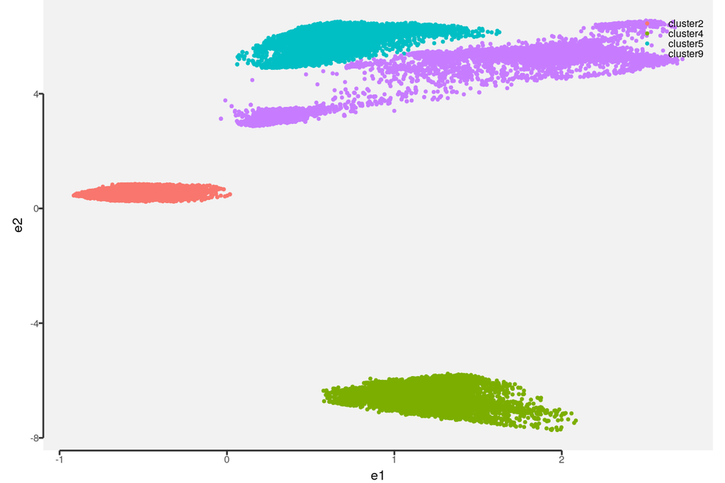

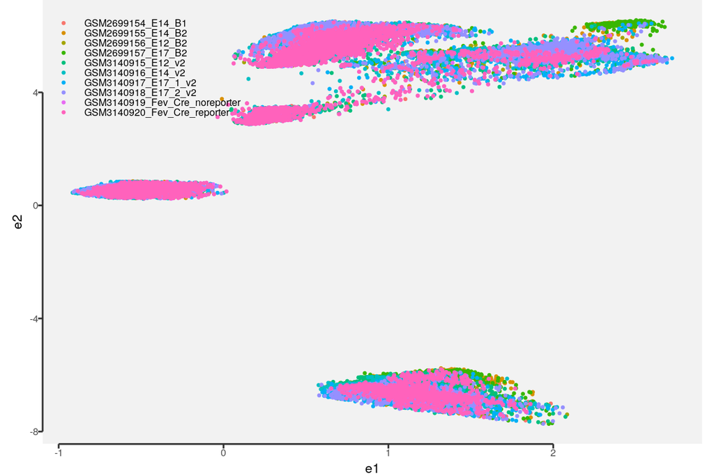

```r
.show.scatter(out.dir %&% "/gmm.argmax.gz",
              out.dir %&% "/gmm.embedded.gz")
```

### Density-based spectral clustering

A strong distributional assumption of underlying data often result in poor clustering results while density-based non-parametric clustering methods robustly identify clusters of data points distributed in an arbitrary fashion.

```bash
if ! [ -f example/pancreas_2018-08-13/dbscan_level_1.argmax.gz ]; then
    mmutil_spectral_cluster_col --mtx example/pancreas_2018-08-13/top.mtx.gz \
                                --rank 5 --epsilon 0.05 --embedding_epochs 30 \
                                --method DBSCAN --knn 100 --prune_knn \
                                --min_size 100 --log_scale --verbose \
                                --col example/pancreas_2018-08-13/top.barcodes.tsv.gz \
                                --out example/pancreas_2018-08-13/dbscan 2> /dev/null
fi
```

```
## <histogram>
##          0 [      1156] ***************************
##          1 [       318] ********
##          2 [       296] *******
##          3 [       180] *****
##          4 [       129] ***
##          5 [       129] ***
## </histogram>
## <histogram>
##          0 [      1213] ***********************
##          1 [       364] *******
##          2 [       304] ******
##          3 [       193] ****
##          4 [       180] ****
##          5 [       180] ****
```

[output cut: 99 more lines]

Read and show DBSCAN estimation at level 1:

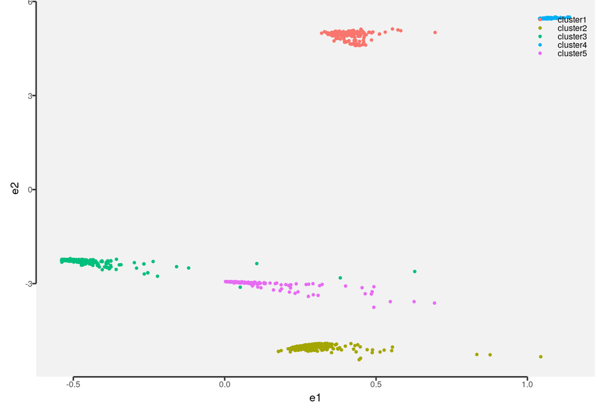

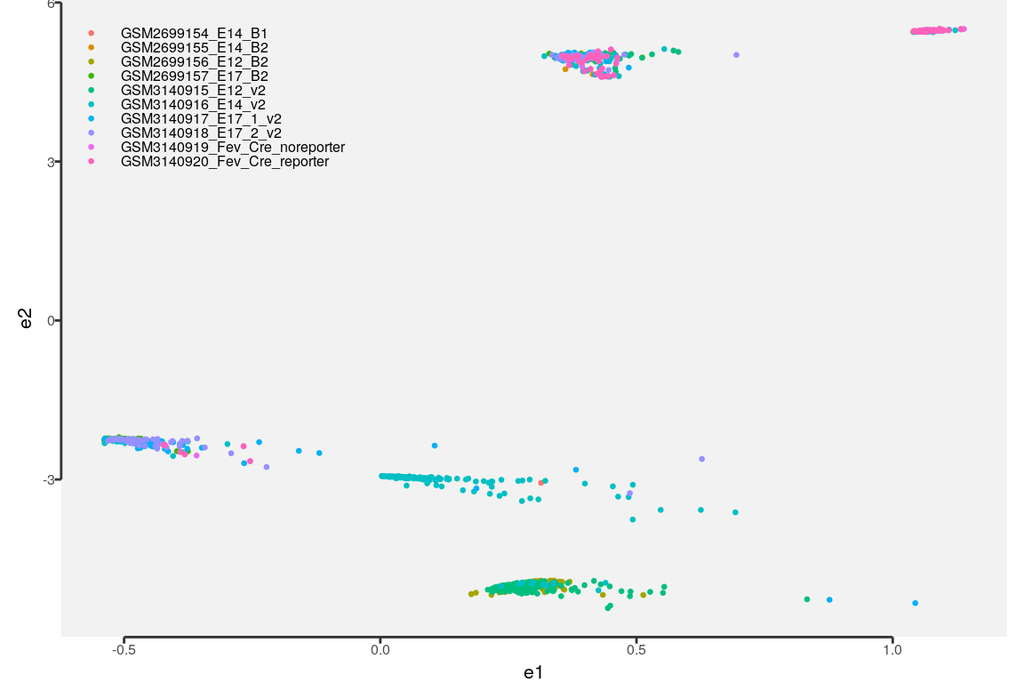

```r
.show.scatter(out.dir %&% "/dbscan_level_1.argmax.gz",
              out.dir %&% "/dbscan_level_1.embedded.gz")
```

Read and show DBSCAN estimation at level 2:

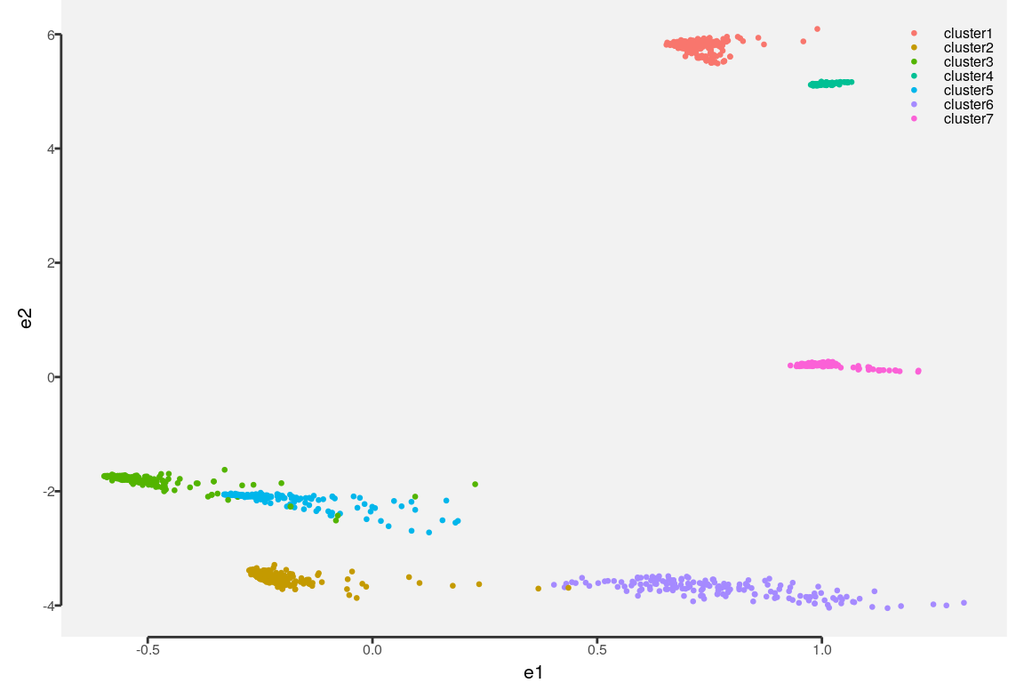

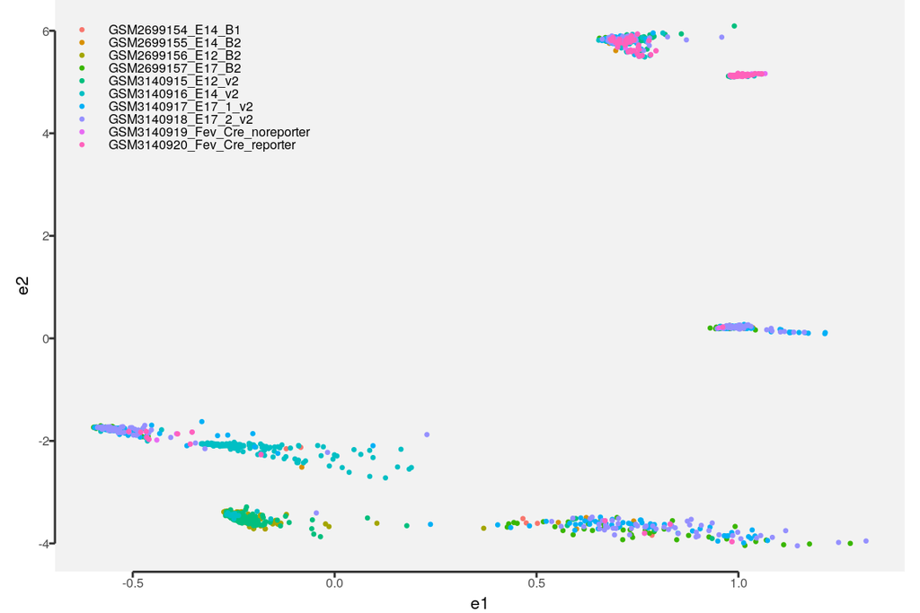

```r
.show.scatter(out.dir %&% "/dbscan_level_2.argmax.gz",
              out.dir %&% "/dbscan_level_2.embedded.gz")
```

Read and show DBSCAN estimation at level 3:

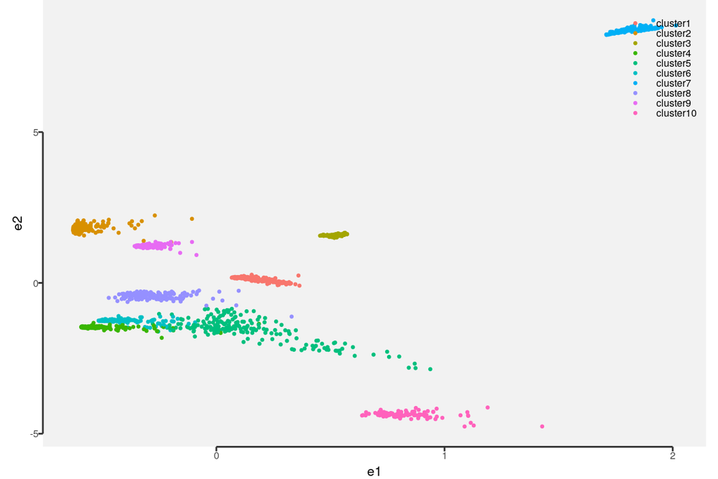

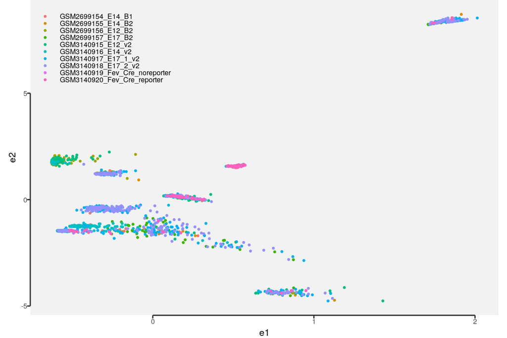

```r
.show.scatter(out.dir %&% "/dbscan_level_3.argmax.gz",
              out.dir %&% "/dbscan_level_3.embedded.gz")
```

## Show the results on E14.5

```bash
export BATCHES=$(ls -1 data/pancreas_2018-08-13/*E14*.mtx.gz | xargs -I file basename file .mtx.gz)

for b in $BATCHES; do
    [ -f example/pancreas_2018-08-13/${b}_genes.tsv.gz ] || gzip -cd data/pancreas_2018-08-13/${b}_genes.tsv.gz | awk '{ print $2 }' | gzip > example/pancreas_2018-08-13/${b}_genes.tsv.gz

    [ -f example/pancreas_2018-08-13/${b}_barcodes.tsv.gz ] || gzip -cd data/pancreas_2018-08-13/${b}_barcodes.tsv.gz | awk -v batch=${b} -F'-' '{ print $1 FS batch }' | gzip > example/pancreas_2018-08-13/${b}_barcodes.tsv.gz
done

if ! [ -f example/pancreas_2018-08-13/merged_e14.mtx.gz ]; then

    mmutil_merge_col \
        example/pancreas_2018-08-13/genes.tsv.gz 500 \
        example/pancreas_2018-08-13/merged_e14 \
        $(echo $BATCHES | sed 's/ /\n/g' | awk '{ print "data/pancreas_2018-08-13/" $1 ".mtx.gz" FS  "example/pancreas_2018-08-13/" $1 "_genes.tsv.gz" FS "example/pancreas_2018-08-13/" $1 "_barcodes.tsv.gz" }')

fi

# just copy the barcode file to be consistent
if ! [ -f example/pancreas_2018-08-13/merged_e14.barcodes.tsv.gz ]; then
    zcat example/pancreas_2018-08-13/merged_e14.columns.gz | \
    awk '{ print $1 }' | \
    gzip > example/pancreas_2018-08-13/merged_e14.barcodes.tsv.gz
fi
```

[output not shown]

[output cut: 127 more lines]

[output not shown]

### Gaussian Mixture Model after spectral transformation

```bash
if ! [ -f example/pancreas_2018-08-13/gmm_e14.argmax.gz ]; then
    mmutil_spectral_cluster_col --mtx example/pancreas_2018-08-13/merged_e14.mtx.gz \
                                --method GMM --trunc 10 --verbose --rank 5 \
                                --kmeanspp --burnin 100 --log_scale \
                                --embedding_epochs 30 \
                                --col example/pancreas_2018-08-13/merged_e14.barcodes.tsv.gz \
                                --out example/pancreas_2018-08-13/gmm_e14 2> /dev/null
fi
```

```
## <histogram>
##          2 [      6623] ********************
##          0 [      4532] **************
##          4 [      2778] *********
##          9 [      1694] ******
##          8 [      1187] ****
##          6 [         0] *
##          5 [         0] *
##          1 [         0] *
##          7 [         0] *
##          3 [         0] *
## </histogram>
```

Read and show GMM_E14 estimation results:

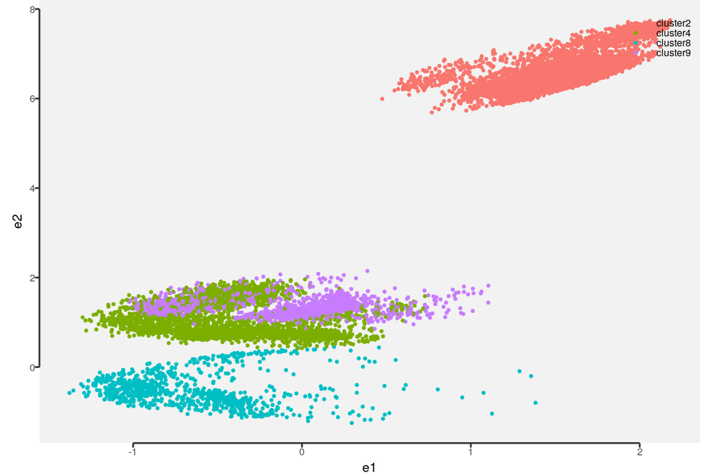

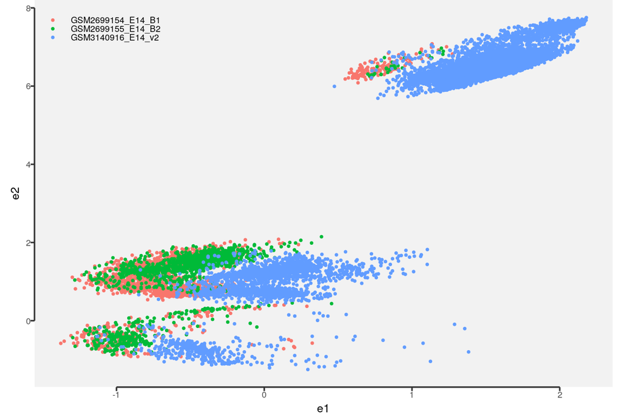

```r
.show.scatter(out.dir %&% "/gmm_e14.argmax.gz",
              out.dir %&% "/gmm_e14.embedded.gz")
```

### Density-based spectral clustering

A strong distributional assumption of underlying data often result in poor clustering results while density-based non-parametric clustering methods robustly identify clusters of data points distributed in an arbitrary fashion.

```bash
if ! [ -f example/pancreas_2018-08-13/dbscan_e14_level_1.argmax.gz ]; then
    mmutil_spectral_cluster_col --mtx example/pancreas_2018-08-13/merged_e14.mtx.gz \
                                --rank 5 --epsilon 0.05 --embedding_epochs 30 \
                                --method DBSCAN --knn 100 --prune_knn \
                                --min_size 10 --log_scale --verbose \
                                --col example/pancreas_2018-08-13/merged_e14.barcodes.tsv.gz \
                                --out example/pancreas_2018-08-13/dbscan_e14 2> /dev/null
fi
```

```
## <histogram>
##          0 [       248] *****************************************
##          1 [        56] **********
## </histogram>
## <histogram>
##          0 [       349] ****************************************
##          1 [        95] ***********
## </histogram>
## <histogram>
##          0 [       375] *************************************
##          1 [       115] ************
##          2 [        22] ***
## </histogram>
## <histogram>
##          0 [       389] ************************************
```

[output cut: 53 more lines]

Read and show DBSCAN estimation at level 1:

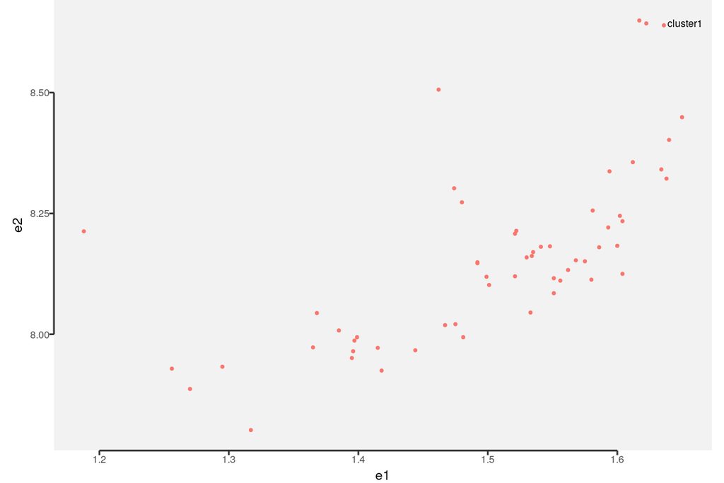

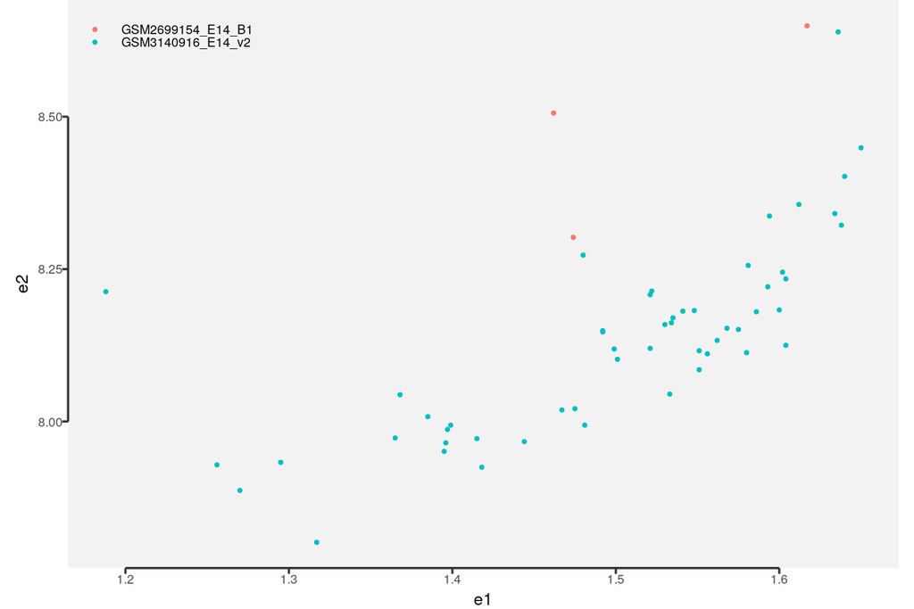

```r
.show.scatter(out.dir %&% "/dbscan_e14_level_1.argmax.gz",
              out.dir %&% "/dbscan_e14_level_1.embedded.gz")
```

Read and show DBSCAN estimation at level 2:

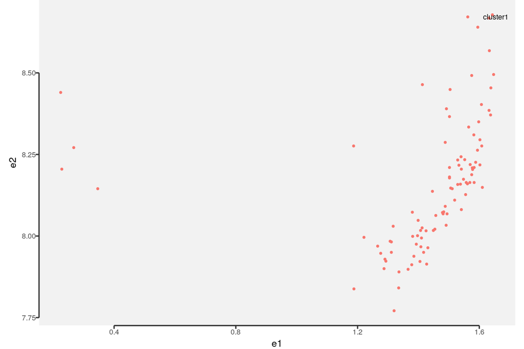

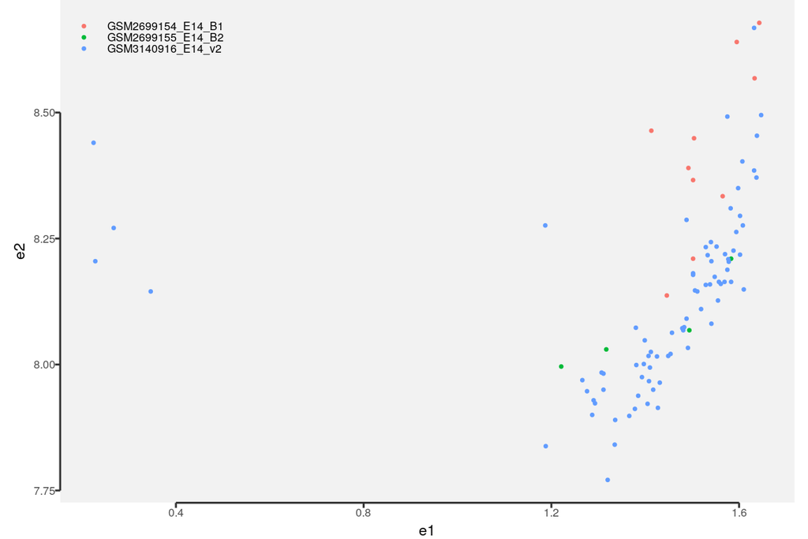

```r
.show.scatter(out.dir %&% "/dbscan_e14_level_2.argmax.gz",
              out.dir %&% "/dbscan_e14_level_2.embedded.gz")
```

Read and show DBSCAN estimation at level 3:

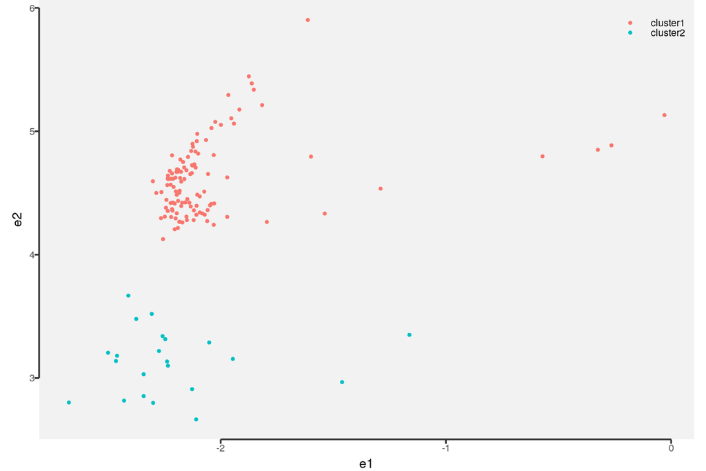

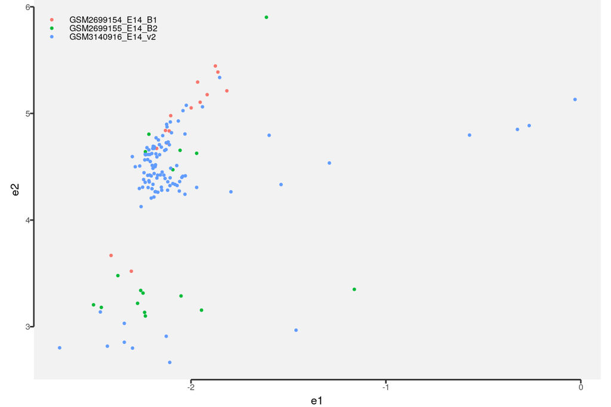

```r
.show.scatter(out.dir %&% "/dbscan_e14_level_3.argmax.gz",
              out.dir %&% "/dbscan_e14_level_3.embedded.gz")
```

Read and show DBSCAN estimation at level 8:

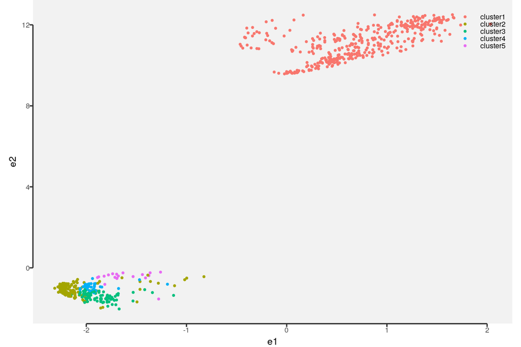

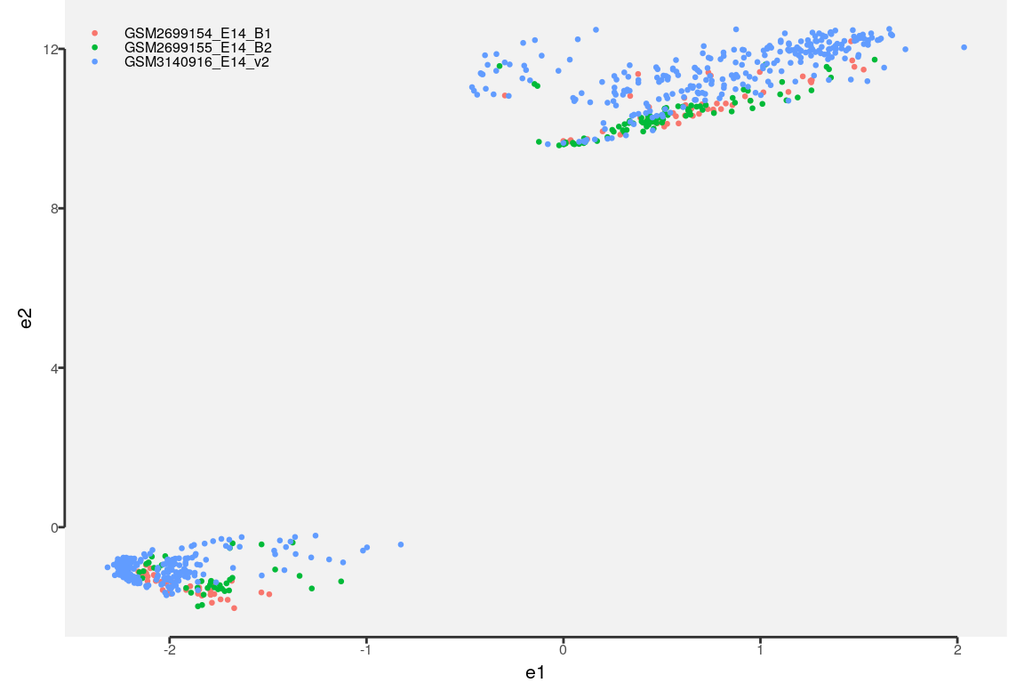

```r
.show.scatter(out.dir %&% "/dbscan_e14_level_8.argmax.gz",
              out.dir %&% "/dbscan_e14_level_8.embedded.gz")
```